# Using the Thonny Python IDE

Thonny is an **IDE** (**I**ntegrated **D**evelopment **E**nvironment) for Python. It works well with MicroPython on a microcontroller, and it also works with CPython (“regular” Python) on a PC. This is good because one environment works for many different programming jobs. It is challenging because it can be a bit confusing; *you* need to keep track of which computer is running your programs.

## Installing Thonny

The program is available for Windows™, MacOS™, and Linux at https://thonny.org with a download box near the top of the page. In case you have any trouble, there are instructions near the bottom of the page.

### Extensions and Configuration

To make Thonny work well for ME405, you can apply a few tweaks.

- Make sure the **Files**, **Shell** (terminal), and **Variables** windows are open. Choose menu item **View** and make sure each is checked. You might like to try other windows as well. If your screen is small, you need not keep the Variables window open all the time.

  Your Thonny window should look similar to the following:

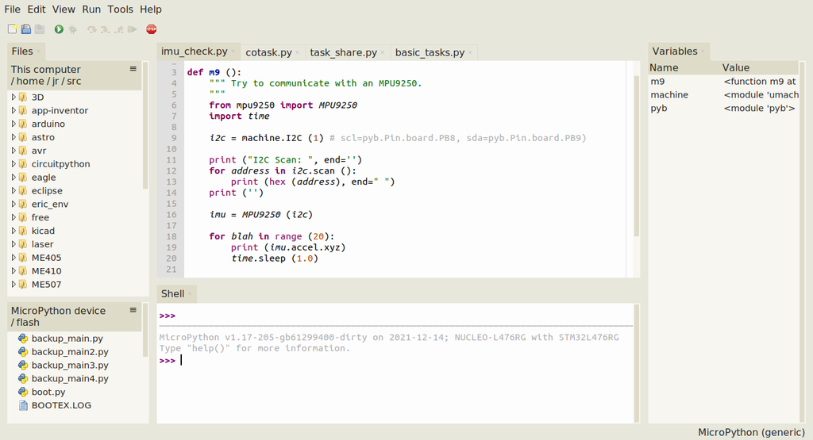

- You will need the **Matplotlib** package, a CPython extension, to make plots later in the course. To install Matplotlib, choose menu item **Tools -> Manage packages…** and search for `Matplotlib` as shown in the image below.

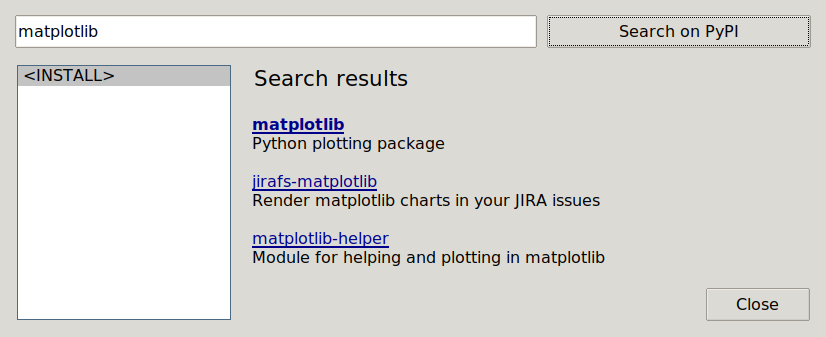

  Click on the **matplotlib** (Python plotting package) link, then the **Install** button. When the installer says “Done” click **Close**.
- If you’d like to change the color scheme, use menu item **Tools -> Options…** and the **Theme & Font** tab. (This is clearly a bug; it should have been “Theme **and** Font” or “Theme **&&** Font.” That’s not a *bitwise* and.)

## Running Python on a PC or a Nucleo

Thonny is itself a Python program. By default, Thonny runs your code in the same Python interpreter as the one used to run Thonny – **on your PC.**

- To run programs on a microcontroller such as a Nucleo™, first plug the microcontroller into a USB port on your PC. Then choose menu item **Run -> Select Interpreter…** and select **MicroPython (Generic)**. Leave (or set) the port to **<Try to detect port automatically>** as shown below, then click **OK**:

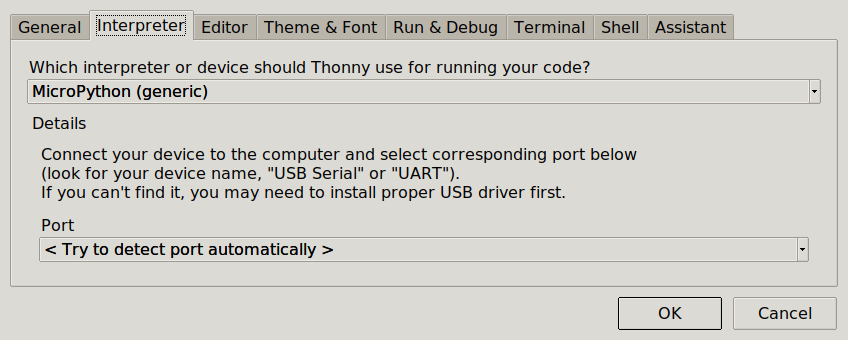

  If **<Try to detect port automatically>** doesn’t work, you may need to manually select the USB-serial port connected to your microcontroller. Commonly used port names (with various numbers *n*) are `COM`*n* for Windows™, `/dev/tty.usbserial`*n* for MacOS™, and `/dev/ttyACM`*n* or `/dev/ttyUSB`*n* for Linux.

  If you have successfully connected to your microcontroller, you should see a screen similar to that shown below in the Thonny terminal window:

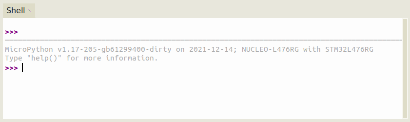

  You can run code on the Nucleo by moving the mouse cursor to the `>>>` Python prompt and typing commands followed by the *Enter* key.
- You can switch back to using Thonny to program your PC by choosing **Run -> Select interpreter…** again and selecting **The same interpreter which runs Thonny**. This should give a terminal display similar to that below:

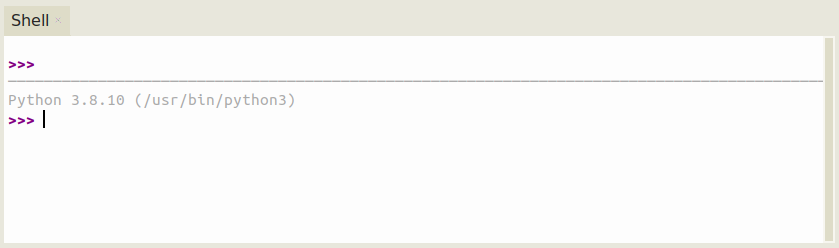

### Running MicroPython Code

When you have plugged in a MicroPython board and selected the MicroPython interpreter, you can run code in three ways:

- Type code one line at a time at the `>>>` prompt in the same way as on a PC.
- Write code in the editor window, save it as a file, and run it by choosing menu item **Run -> Run current script** or pressing **F5** or clicking the green “play” button.
- Create Python files, upload them to the `/flash` folder of the MicroPython board, and run them from there. The file `main.py` will run every time the board is rebooted:
  - If you type **Ctrl-D** in Thonny or press the **Stop/Restart backend** button, MicroPython will restart and run `main.py`.
  - If you press the reset button on the board (for example, the black button on a Nucleo), MicroPython will restart. You may have to press the **Stop/Restart backend** button after rebooting your board this way.
  - If you plug in a MicroPython board with its USB cable, `main.py` will run whether the board is connected to Thonny or not.

### Running PC Code

When you have selected the same interpreter that runs Thonny on your PC, there are many ways to run CPython code on your PC. Two common ways are:

- Type code one line at a time directly into the Shell at the `>>>` prompt. You’ll see an immediate response, unless you’ve typed part of a multi-line instruction such as a loop. In that case, Thonny will indent following lines; press **Enter** twice to make an empty line and end the compound statement.
- Write code in the editor window, save it as a file, and run it by choosing menu item **Run -> Run current script** or pressing **F5** or clicking the green “play” button.